# Homework 4

*Ginevra Carbone*

## Exercise 1

*Above we found that the posterior mean is a weighted mean of the prior belief and the likelihood mean. Using some simple algebra, retrieve other two alternative expression and provide a nice interpretation.*

$$\begin{aligned}
\mu^* &= \frac{n\tau^2 \bar{y}+\sigma^2 \mu}{n \tau^2 +\sigma^2} \\
&= \bar{y} + \frac{n\tau^2 \bar{y}+\sigma^2 \mu - n\tau^2 \bar{y} -\sigma^2 \bar{y}}{n \tau^2 +\sigma^2} \\
&= \bar{y} - (\bar{y}-\mu)\frac{\sigma^2}{n\tau^2+\sigma^2}
\end{aligned}$$
Here the posterior mean is expressed as the sample mean plus an adjustment toward the prior mean. From this expression one can easily notice that, as previously pointed out, $\lim_{n\rightarrow \infty} \mu^* = \bar{y}$ and $\lim_{\tau \rightarrow 0} \mu^* = \mu$.

$$\begin{aligned}
\mu^* &= \frac{n\tau^2 \bar{y}+\sigma^2 \mu}{n \tau^2 +\sigma^2} \\
& = \mu + \frac{n\tau^2 \bar{y}+\sigma^2 \mu - n \tau^2\mu-\sigma^2 \mu }{n \tau^2 +\sigma^2}\\
&= \mu + (\bar{y}-\mu) \frac{n \tau^2}{n\tau^2+\sigma^2}
\end{aligned}$$

In this case the posterior mean is expressed as the prior mean plus an adjustment toward the sample mean.

## Exercise 2

*In `sim` in the code above, you find the MCMC output which allows for approximating the posterior distribution of our parameter of interest with $S$ draws of $\theta$. Please, produce an histogram for these random draws $\theta^{(1)},\dots,\theta^{(S)}$ compute the empirical quantiles, and overlap the true posterior distribution.*

```r
#input values
#true mean
theta_sample <- 2
#likelihood variance
sigma2 <- 2
#sample size
n <- 10
#prior mean
mu <- 7
#prior variance
tau2 <- 2
#generate some data
set.seed(123)
y <- rnorm(n,theta_sample, sqrt(sigma2))
#posterior mean
mu_star <- ((1/tau2)*mu+(n/sigma2)*mean(y))/( (1/tau2)+(n/sigma2))
#posterior standard deviation
sd_star <- sqrt(1/( (1/tau2)+(n/sigma2)))
library(rstan)
data<- list(N=n, y=y, sigma =sqrt(sigma2), mu = mu, tau = sqrt(tau2))
fit <- stan(file="stan/normal.stan", data = data, chains = 4, iter=2000)
```

[output not shown]

[output cut: 38 more lines]

[output not shown]

```r
#extract Stan output
sim <- extract(fit)
# MCMC posterior
hist(sim$theta, breaks=40, xlim = c(0,5), probability = TRUE)
# true posterior
curve(dnorm(x, mu_star, sd_star),
  xlab=expression(theta), ylab="", col="blue", lwd=2, add=T)
```

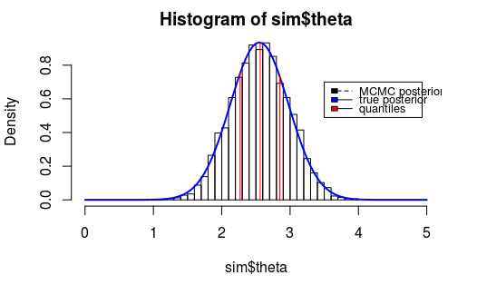

```r
# compute empirical quantiles
qt <- quantile(sim$theta)
segments(qt, 0, qt, dnorm(qt, mu_star, sd_star),  col = 2)
legend(3.5, 0.7, c("MCMC posterior", "true posterior", "quantiles"), c("black", "blue", "red" ), lty=c(2,1,1),lwd=c(1,1,1), cex=0.8)
```

## Exercise 3

*Suppose you receive $n=15$ phone calls in a day, and you want to build a model for assessing their average length. Your likelihood for each call length is $y_i\sim Poisson(\lambda)$. Now, you have to choose the prior $\pi(\lambda)$. Please, tell which of these priors is adequate for describing the problem, and provide a short motivation for each of them:*

1. $\pi(\lambda)=Beta(4,2)$
2. $\pi(\lambda)=Normal(1,2)$
3. $\pi(\lambda)=Gamma(4,2)$

*Now, compute your posterior as $\pi(\lambda | y) \propto L(\lambda;y) \pi(\lambda)$ for the selected prior. If your first choice was correct, you will be able to compute it analitically.*

If $y_i\sim Poisson(\lambda)$, then a $Gamma$ prior on $\lambda$ is a conjugate prior, because from

$$\pi(\lambda) = \frac{\beta^\alpha}{\Gamma(\alpha)}\lambda^{\alpha-1}e^{-\beta\lambda}$$
$$L(\lambda ; y) = \frac{e^{-n \lambda}\lambda^{\sum y_i}}{\prod_{i=1}^n (y_i !)}$$

we have $\pi(\lambda | y) \propto Gamma(\sum y_i + \alpha, n +\beta)$. Therefore, the adequate prior is $Gamma(4,2)$. We could also exclude the other two cases a priori, since a normal distribution also takes negative values, while a beta distribution is defined over the interval $[0,1]$.

```r
#generate some data from a poisson distribution
set.seed(123)
n = 15
lambda_sample = 1
y <- rpois(n, lambda_sample)
# gamma prior
alpha = 4
beta = 2
curve(dgamma(x, alpha, beta), xlim=c(-2,8), col="blue",
      lty=1,lwd=2, ylim=c(0,2.2), ylab="density")
# beta prior
curve(dbeta(x, 4, 2), xlim=c(-2,8), col="blue", lty=2,
      lwd=1, add =T)
```

```r
# normal prior
curve(dnorm(x, 1, 2), xlim=c(-2,8), col="blue", lty=3,
      lwd=1, add =T)
# gamma posterior
alpha_star = sum(y) + alpha
beta_star = n + beta
curve(dgamma(x, alpha_star, beta_star),
      xlab=expression(theta), ylab="", col="red", lwd=2, add=T)
```

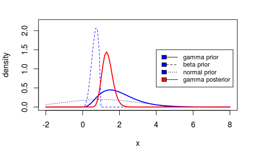

```r
legend(4, 1.5,
       c("gamma prior", "beta prior", "normal prior","gamma posterior"),
       c("blue", "blue","blue", "red" ),
       lty=c(1,2,3,1), lwd=c(1,1,1), cex=0.8)
```

## Exercise 4

*Open the file model called `biparametric.stan` and replace the line `target+=cauchy_lpdf(sigma|0,2.5);` with the following one: `target+=uniform_lpdf(sigma|0.1,10);`.*

*Which prior are you now assuming for your parameter $\sigma$? Reproduce the same plots as above and briefly comment.*

```r
library("bayesplot")
library("ggplot2")
#input values
#true mean
theta_sample <- 2
#likelihood variance
sigma2 <- 2
#sample size
n <- 10
#prior mean
mu <- 7
#prior variance
tau2 <- 2
#generate some data
set.seed(123)
y <- rnorm(n,theta_sample, sqrt(sigma2))
#launch biparametric Stan model
data3<- list(N=n, y=y, a=-10, b=10)
fit3 <- stan(file="stan/biparametric.stan", data = data3, chains = 4, iter=2000, refresh=-1)
```

[output not shown]

```
There were 2 divergent transitions after warmup. Increasing adapt_delta above 0.8 may help. See
http://mc-stan.org/misc/warnings.html#divergent-transitions-after-warmupThere were 1 transitions after warmup that exceeded the maximum treedepth. Increase max_treedepth above 10. See
http://mc-stan.org/misc/warnings.html#maximum-treedepth-exceededExamine the pairs() plot to diagnose sampling problems
```

```r
#extract stan output for biparametric model
sim3 <- extract(fit3)
posterior_biv <- as.matrix(fit3)
theta_est <- mean(sim3$theta)
sigma_est <- mean(sim3$sigma)
c(theta_est, sigma_est)
```

```
[1] 2.099920 1.588445
```

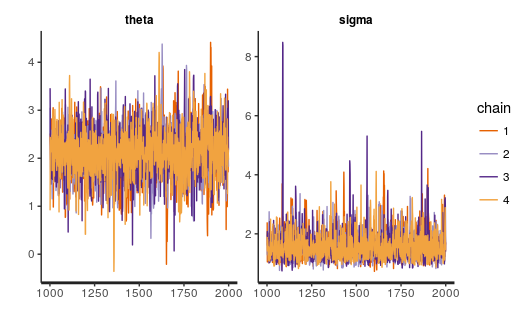

```r
traceplot(fit3, pars=c("theta", "sigma"))
```

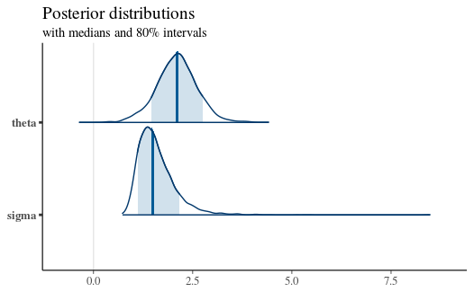

```r
plot_title <- ggtitle("Posterior distributions",
                      "with medians and 80% intervals")
mcmc_areas(posterior_biv,
           pars = c("theta","sigma"),
           prob = 0.8) + plot_title
```

In this case we are assuming that $\sigma \sim Unif(0.1,10)$, obtaining different mean and variance for both $\theta$ and $\sigma$ posterior distributions.

## Exercise 5

*Reproduce the first plot above for the soccer goals, but this time by replacing Prior 1 with a `Gamma(2,4)`. Then, compute the final Bayes factor matrix (`BF_matrix`) with this new prior and the other ones unchanged, and comment. Is still Prior 2 favorable over all the others?*

```r
library(LearnBayes)
data(soccergoals)
y <- soccergoals$goals
#write the likelihood function via the gamma distribution
lik_pois<- function(data, theta){
  n <- length(data)
  lambda <- exp(theta)
  dgamma(lambda, shape =sum(data)+1, scale=1/n)
}
prior_gamma <- function(par, theta){
  lambda <- exp(theta)
  dgamma(lambda, par[1], rate=par[2])*lambda
}
prior_norm <- function(npar, theta){
  lambda=exp(theta)
  (dnorm(theta, npar[1], npar[2]))

}
lik_pois_v <- Vectorize(lik_pois, "theta")
prior_gamma_v <- Vectorize(prior_gamma, "theta")
prior_norm_v <- Vectorize(prior_norm, "theta")
#likelihood
curve(lik_pois_v(theta=x, data=y), xlim=c(-4,5), xlab=expression(theta), ylab = "density", lwd =2 )
#prior 1
curve(prior_gamma_v(theta=x, par=c(4, 2)), lty =2, col="red", add = TRUE, lwd =2)
```

```r
#prior 2
curve(prior_norm_v(theta=x, npar=c(1, .5)), lty =3, col="blue", add =TRUE, lwd=2)
#prior 3
curve(prior_norm_v(theta=x, npar=c(2, .5)), lty =4, col="green", add =TRUE, lwd =2)
```

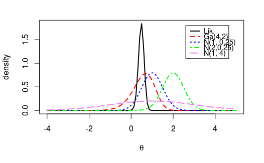

```r
#prior 4
curve(prior_norm_v(theta=x, npar=c(1, 2)), lty =5, col="violet", add =TRUE, lwd =2)
legend(2.6, 1.8, c("Lik.", "Ga(4,2)", "N(1, 0.25)", "N(2,0.25)","N(1, 4)" ), lty=c(1,2,3,4,5), col=c("black", "red", "blue", "green", "violet"),lwd=2, cex=0.9)
```

```r
logpoissongamma <- function(theta, datapar){
   data <- datapar$data
   par <- datapar$par
   lambda <- exp(theta)
   log_lik <- log(lik_pois(data, theta))
   log_prior <- log(prior_gamma(par, theta))
   return(log_lik+log_prior)
}
logpoissongamma.v <- Vectorize( logpoissongamma, "theta")
logpoissonnormal <- function( theta, datapar){
 data <- datapar$data
 npar <- datapar$par
 lambda <- exp(theta)
 log_lik <- log(lik_pois(data, theta))
 log_prior <- log(prior_norm(npar, theta))
  return(log_lik+log_prior)
}
logpoissonnormal.v <- Vectorize( logpoissonnormal, "theta")
#log-likelihood
curve(log(lik_pois(y, theta=x)), xlim=c(-1,2),ylim=c(-20,2), lty =1,
   ylab="log-posteriors", xlab=expression(theta))
#log posterior 1
curve(logpoissongamma.v(theta=x, list(data=y, par=c(4, 2))), col="red", xlim=c(-1,4),ylim=c(-20,2), lty =1, add =TRUE)
```

```r
#log posterior 2
 curve(logpoissonnormal.v( theta=x, datapar <- list(data=y, par=c(1, .5))), lty =1, col="blue",  add =TRUE)
#log posterior 3
 curve(logpoissonnormal.v( theta=x, datapar <- list(data=y, par=c(2, .5))), lty =1, col="green", add =TRUE, lwd =2)
```

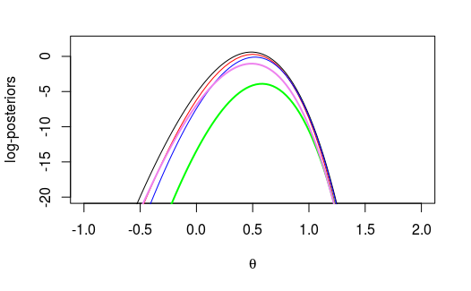

```r
#log posterior 4
  curve(logpoissonnormal.v( theta=x, list(data=y, par=c(1, 2))), lty =1, col="violet", add =TRUE, lwd =2)
 legend(2.6, 1.3, c( "loglik", "lpost 1", "lpost 2", "lpost 3", "lpost 4" ), lty=1, col=c("black", "red", "blue", "green", "violet"),lwd=2, cex=0.9)
```

```r
datapar <- list(data=y, par=c(4, 2))
fit1 <- laplace(logpoissongamma, .5, datapar)
```

```
one-dimensional optimization by Nelder-Mead is unreliable:
use "Brent" or optimize() directly
```

```r
datapar <- list(data=y, par=c(1, .5))
fit2 <- laplace(logpoissonnormal, .5, datapar)
```

```
one-dimensional optimization by Nelder-Mead is unreliable:
use "Brent" or optimize() directly
```

```r
datapar <- list(data=y, par=c(2, .5))
fit3 <- laplace(logpoissonnormal, .5, datapar)
```

```
one-dimensional optimization by Nelder-Mead is unreliable:
use "Brent" or optimize() directly
```

```r
datapar <- list(data=y, par=c(1, 2))
fit4 <- laplace(logpoissonnormal, .5, datapar)
```

```
one-dimensional optimization by Nelder-Mead is unreliable:
use "Brent" or optimize() directly
```

```r
postmode <- c(fit1$mode, fit2$mode, fit3$mode, fit4$mode )
postsds <- sqrt(c(fit1$var, fit2$var, fit3$var, fit4$var))
logmarg <- c(fit1$int, fit2$int, fit3$int, fit4$int)
cbind(postmode, postsds, logmarg)
```

```
      postmode   postsds    logmarg
[1,] 0.4999512 0.1280372 -0.8440147
[2,] 0.5207825 0.1260712 -1.2551710
[3,] 0.5825195 0.1224723 -5.0763156
[4,] 0.4899414 0.1320165 -2.1372163
```

```r
BF_matrix <- matrix(1, 4,4)
for (i in 1:3){
  for (j in 2:4){
   BF_matrix[i,j]<- exp(logmarg[i]-logmarg[j])
   BF_matrix[j,i]=(1/BF_matrix[i,j])
  }
}
round_bf <- round(BF_matrix,3)
round_bf
```

```
      [,1]  [,2]   [,3]  [,4]
[1,] 1.000 1.509 68.876 3.644
[2,] 0.663 1.000 45.656 2.416
[3,] 0.015 0.022  1.000 0.053
[4,] 0.274 0.414 18.899 1.000
```

I suspect there’s an error in the assignment, since if I replace Prior 1 with a $Gamma(4,2)$ (instead of $Gamma(2,4)$) It becomes the favorable one over the others.

## Exercise 6

*Let $y=(1,0,0,1,0,0,0,0,0,1,0,0,1,0)$ collect the results of tossing $n=14$ times an unfair coin, where 1 denotes heads and 0 crosses, and $p=Prob(y_i=1)$.*

- *Looking at the `Stan` code for the other models, write a short `Stan` Beta-Binomial model, where $p$ has a $Beta(a,b)$ prior with $a=3, b=3$;*
- *Extract the posterior distribution with the function `extract()`;*
- *Compute analitically the posterior distribution and compare it with the `Stan` distribution.*

```r
# data
y <- c(1,0,0,1,0,0,0,0,0,1,0,0,1,0)
#sample size
n <- length(y)
# success probability
sample_prob <- sum(y)/n
# prior
alpha <- 3
beta <- 3
curve(dbeta(x, alpha, beta), xlim=c(-0.5,1.5), ylim=c(0,4), col="red", lty=1,lwd=2, ylab="density")
#launch Stan model
data <- list(N=n, y=sum(y), alpha=3, beta=3)
fit <- stan(file="stan/beta_binomial.stan", data = data,
            chains = 4, iter=2000)
```

[output not shown]

[output cut: 83 more lines]

[output not shown]

```
There were 15 divergent transitions after warmup. Increasing adapt_delta above 0.8 may help. See
http://mc-stan.org/misc/warnings.html#divergent-transitions-after-warmupExamine the pairs() plot to diagnose sampling problems
```

```r
#extract Stan output
sim <- extract(fit)
#stan simulated posterior
lines(density(sim$p, adj=2), col ="black", lwd=1, lty =2)
```

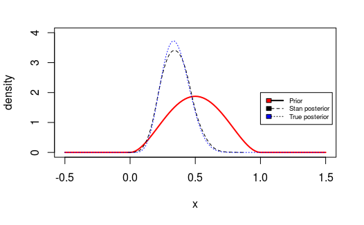

```r
# true posterior
alpha_star <- alpha + sum(y)
beta_star <- beta + n - sum(y)
curve(dbeta(x, alpha_star , beta_star), lty=3, lwd=1,
      col="blue", add=T)
legend(1, 2, c("Prior", "Stan posterior", "True posterior"),
       c("red", "black", "blue"), lty=c(1,2,3),
       lwd=c(2,1,1), cex=0.6)
```